# Personal Loan Campaign Modelling

### Decision Tree Model

We will now train a decision tree model of the dataset. We will compensate for the class imbalance by using 'class_weight="balanced"' which automatically adjusts weights to be inversely proportional to the class frequencies.

```python
# get features list for later visualization
feature_names = list(X_train.columns)

# train the decision tree
dtm = DecisionTreeClassifier(
    criterion="gini", class_weight='balanced', random_state=1
)
dtm.fit(X_train, y_train)
```

```
DecisionTreeClassifier(class_weight='balanced', random_state=1)
```

```python
get_metrics_score(dtm, X_train, X_test, y_train, y_test);
```

```
Accuracy - training      :  1.0
Accuracy - test          :  0.9766666666666667
Recall - training        :  1.0
Recall - test            :  0.8590604026845637
Precision - training     :  1.0
Precision - test         :  0.9014084507042254
F1 - training            :  1.0
F1 - test                :  0.8797250859106529
```

```
Accuracy=1.000
Precision=1.000
Recall=1.000
F1 Score=1.000
```

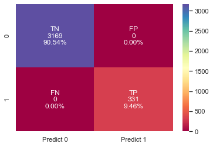

```python
# plot confusion metrics - TRAIN data
plot_confusion_matrix(dtm,X_train, y_train)
```

```
Accuracy=0.977
Precision=0.901
Recall=0.859
F1 Score=0.880
```

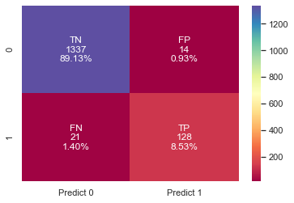

```python
# plot confusion metrics - TEST data
plot_confusion_matrix(dtm,X_test, y_test)
```

Although Precision and Recall are high for the test dataset, the model is overfitting.

#### Visualizing the decision tree

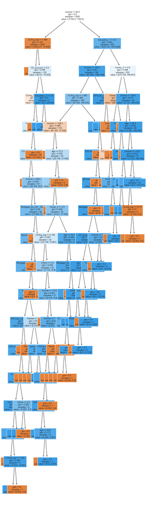

```python
plt.figure(figsize=(10,40))
out = tree.plot_tree(
    dtm,
    feature_names=feature_names,
    filled=True,
    fontsize=9,
    node_ids=False,
    class_names=None,
)
# below code will add arrows to the decision tree split if they are missing
for o in out:
    arrow = o.arrow_patch
    if arrow is not None:
        arrow.set_edgecolor("black")
        arrow.set_linewidth(1)
plt.show()
```

#### Decision tree in text format

```python
# Text report with rules of decision tree
print(tree.export_text(dtm, feature_names=feature_names, show_weights=True, max_depth=20))
```

```
|--- Income <= 92.50
|   |--- CCAvg_log <= 1.10
|   |   |--- weights: [1344.67, 0.00] class: 0
|   |--- CCAvg_log >  1.10
|   |   |--- CD_Account <= 0.50
|   |   |   |--- CCAvg_log <= 1.39
|   |   |   |   |--- Family_4 <= 0.50
|   |   |   |   |   |--- CCAvg_log <= 1.13
|   |   |   |   |   |   |--- weights: [9.94, 0.00] class: 0
|   |   |   |   |   |--- CCAvg_log >  1.13
|   |   |   |   |   |   |--- Income <= 68.50
|   |   |   |   |   |   |   |--- weights: [4.97, 0.00] class: 0
|   |   |   |   |   |   |--- Income >  68.50
|   |   |   |   |   |   |   |--- Mortgage_bin_201 - 300 <= 0.50
|   |   |   |   |   |   |   |   |--- Securities_Account <= 0.50
|   |   |   |   |   |   |   |   |   |--- Mortgage_bin_101 - 200 <= 0.50
|   |   |   |   |   |   |   |   |   |   |--- Income <= 84.00
|   |   |   |   |   |   |   |   |   |   |   |--- ZIPCode_cat_95616 <= 0.50
|   |   |   |   |   |   |   |   |   |   |   |   |--- ZIPCode_cat_94720 <= 0.50
|   |   |   |   |   |   |   |   |   |   |   |   |   |--- CreditCard <= 0.50
|   |   |   |   |   |   |   |   |   |   |   |   |   |   |--- Income <= 82.50
|   |   |   |   |   |   |   |   |   |   |   |   |   |   |   |--- Online <= 0.50
|   |   |   |   |   |   |   |   |   |   |   |   |   |   |   |   |--- weights: [1.10, 0.00] class: 0
|   |   |   |   |   |   |   |   |   |   |   |   |   |   |   |--- Online >  0.50
|   |   |   |   |   |   |   |   |   |   |   |   |   |   |   |   |--- CCAvg_log <= 1.33
|   |   |   |   |   |   |   |   |   |   |   |   |   |   |   |   |   |--- weights: [0.00, 15.86] class: 1
|   |   |   |   |   |   |   |   |   |   |   |   |   |   |   |   |--- CCAvg_log >  1.33
|   |   |   |   |   |   |   |   |   |   |   |   |   |   |   |   |   |--- weights: [0.55, 0.00] class: 0
|   |   |   |   |   |   |   |   |   |   |   |   |   |   |--- Income >  82.50
|   |   |   |   |   |   |   |   |   |   |   |   |   |   |   |--- weights: [0.00, 26.44] class: 1
|   |   |   |   |   |   |   |   |   |   |   |   |   |--- CreditCard >  0.50
|   |   |   |   |   |   |   |   |   |   |   |   |   |   |--- Online <= 0.50
|   |   |   |   |   |   |   |   |   |   |   |   |   |   |   |--- weights: [0.00, 5.29] class: 1
|   |   |   |   |   |   |   |   |   |   |   |   |   |   |--- Online >  0.50
|   |   |   |   |   |   |   |   |   |   |   |   |   |   |   |--- weights: [1.66, 0.00] class: 0
|   |   |   |   |   |   |   |   |   |   |   |   |--- ZIPCode_cat_94720 >  0.50
|   |   |   |   |   |   |   |   |   |   |   |   |   |--- weights: [0.55, 0.00] class: 0
|   |   |   |   |   |   |   |   |   |   |   |--- ZIPCode_cat_95616 >  0.50
|   |   |   |   |   |   |   |   |   |   |   |   |--- weights: [0.55, 0.00] class: 0
|   |   |   |   |   |   |   |   |   |   |--- Income >  84.00
```

[output cut: 153 more lines]

```
|   |   |   |   |--- weights: [6.07, 0.00] class: 0
|   |   |   |--- Income >  108.50
|   |   |   |   |--- Age <= 26.00
|   |   |   |   |   |--- weights: [0.55, 0.00] class: 0
|   |   |   |   |--- Age >  26.00
|   |   |   |   |   |--- Income <= 118.00
|   |   |   |   |   |   |--- Online <= 0.50
|   |   |   |   |   |   |   |--- weights: [0.00, 10.57] class: 1
|   |   |   |   |   |   |--- Online >  0.50
|   |   |   |   |   |   |   |--- CCAvg_log <= 0.77
|   |   |   |   |   |   |   |   |--- weights: [0.55, 0.00] class: 0
|   |   |   |   |   |   |   |--- CCAvg_log >  0.77
|   |   |   |   |   |   |   |   |--- weights: [0.55, 0.00] class: 0
|   |   |   |   |   |--- Income >  118.00
|   |   |   |   |   |   |--- weights: [0.00, 174.47] class: 1
```

The tree complexity is high and difficult to interpret.

We will pre-prune and post-prune the tree to if we can improve the Precision/Recall and reduce complexity.

#### Features importance

```python
# importance of features using Gini importance
print(
    pd.DataFrame(
        dtm.feature_importances_, columns=["Imp"], index=X_train.columns,
    ).sort_values(by="Imp", ascending=False)
)
```

```
                                 Imp
Income                  6.419375e-01
CCAvg_log               9.340454e-02
Education_1             8.449977e-02
Family_4                8.290791e-02
Family_3                6.238447e-02
Age                     9.733962e-03
CD_Account              7.542309e-03
Online                  5.387966e-03
Mortgage_bin_101 - 200  2.410076e-03
Mortgage_bin_201 - 300  2.143534e-03
Securities_Account      2.141680e-03
Mortgage_bin_0          1.219760e-03
Education_3             1.142857e-03
ZIPCode_cat_95616       1.128285e-03
CreditCard              8.480075e-04
ZIPCode_cat_93943       5.900468e-04
ZIPCode_cat_94720       5.456970e-04
Family_2                3.157595e-05
ZIPCode_cat_90095       8.190830e-16
Education_2             2.515611e-17
Mortgage_bin_301 - 400  0.000000e+00
Mortgage_bin_1 - 100    0.000000e+00
ZIPCode_cat_Other       0.000000e+00
ZIPCode_cat_91320       0.000000e+00
ZIPCode_cat_94305       0.000000e+00
ZIPCode_cat_94025       0.000000e+00
ZIPCode_cat_93106       0.000000e+00
ZIPCode_cat_92037       0.000000e+00
ZIPCode_cat_91711       0.000000e+00
Family_1                0.000000e+00
Mortgage_bin_> 400      0.000000e+00
```

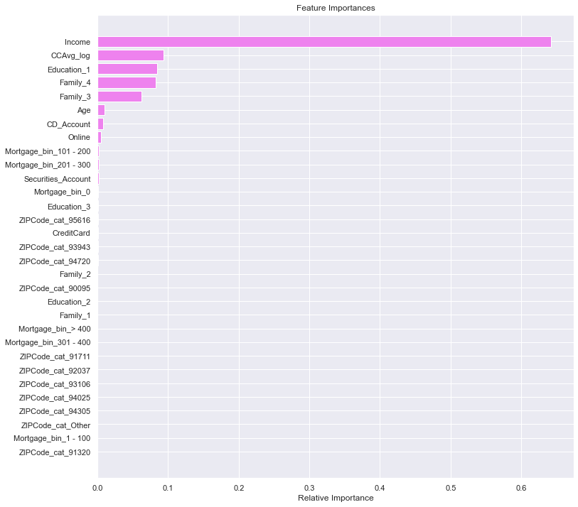

```python
# plot importance graph
importances = dtm.feature_importances_
indices = np.argsort(importances)

plt.figure(figsize=(12, 12))
plt.title("Feature Importances")
plt.barh(range(len(indices)), importances[indices], color="violet", align="center")
plt.yticks(range(len(indices)), [feature_names[i] for i in indices])
plt.xlabel("Relative Importance")
plt.show()
```

Income has the highest predictive value.

### Decision Tree - Reducing Overfitting and Complexity

#### Prepruning - Grid Search

```python
# import required libraries
from sklearn.model_selection import GridSearchCV
```

```python
# Define grid parameters
parameters = {
    "max_depth": range(1, 11),
    "criterion": ['gini','entropy'],
    "splitter": ['best', 'random'],
    "min_impurity_decrease": [0.00001, 0.0001, 0.001, 0.01],
    "max_features": ['log2','sqrt']
}

# Even though we want to optimixe Recall, maximizing Recall alone will create a model with
# very high number of False Positive
scorer = metrics.make_scorer(metrics.f1_score)

# Run the grid search
grid = GridSearchCV(dtm, parameters, scoring=scorer, cv=5)
grid = grid.fit(X_train, y_train)

# Get the best estimator
prep_best_estimator = grid.best_estimator_

# Fit the best estimator
prep_best_estimator.fit(X_train, y_train)
```

```
DecisionTreeClassifier(class_weight='balanced', max_depth=10,
                       max_features='sqrt', min_impurity_decrease=1e-05,
                       random_state=1)
```

```python
# get metrics of the model performance
get_metrics_score(prep_best_estimator, X_train, X_test, y_train, y_test);
```

```
Accuracy - training      :  0.9468571428571428
Accuracy - test          :  0.924
Recall - training        :  0.9697885196374623
Recall - test            :  0.8187919463087249
Precision - training     :  0.6458752515090543
Precision - test         :  0.583732057416268
F1 - training            :  0.7753623188405797
F1 - test                :  0.6815642458100559
```

```
Accuracy=0.924
Precision=0.584
Recall=0.819
F1 Score=0.682
```

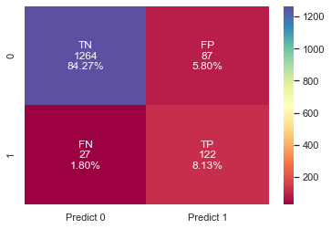

```python
# get performance metrics for TEST
plot_confusion_matrix(prep_best_estimator, X_test, y_test)
```

Recall and Precision are both worse than the full tree. Also the model is still overfitting. (Recall 0.96 for train and 0.82 for test)

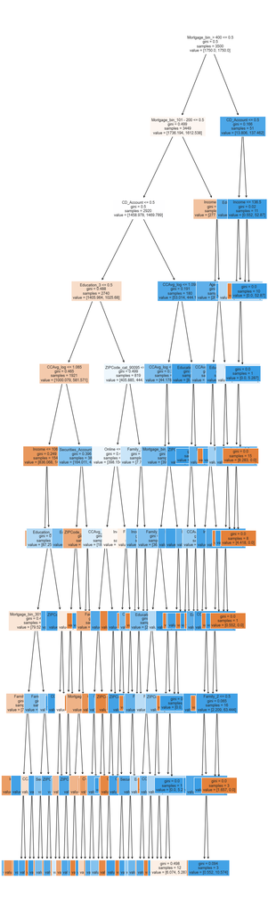

```python
# Review the best estimator tree
plt.figure(figsize=(10,40))
out = tree.plot_tree(
    prep_best_estimator,
    feature_names=feature_names,
    filled=True,
    fontsize=9,
    node_ids=False,
    class_names=None,
)
# below code will add arrows to the decision tree split if they are missing
for o in out:
    arrow = o.arrow_patch
    if arrow is not None:
        arrow.set_edgecolor("black")
        arrow.set_linewidth(1)
plt.show()
```

```python
# Text report with rules of decision tree
print(tree.export_text(dtm, feature_names=feature_names, show_weights=True, max_depth=10))
```

```
|--- Income <= 92.50
|   |--- CCAvg_log <= 1.10
|   |   |--- weights: [1344.67, 0.00] class: 0
|   |--- CCAvg_log >  1.10
|   |   |--- CD_Account <= 0.50
|   |   |   |--- CCAvg_log <= 1.39
|   |   |   |   |--- Family_4 <= 0.50
|   |   |   |   |   |--- CCAvg_log <= 1.13
|   |   |   |   |   |   |--- weights: [9.94, 0.00] class: 0
|   |   |   |   |   |--- CCAvg_log >  1.13
|   |   |   |   |   |   |--- Income <= 68.50
|   |   |   |   |   |   |   |--- weights: [4.97, 0.00] class: 0
|   |   |   |   |   |   |--- Income >  68.50
|   |   |   |   |   |   |   |--- Mortgage_bin_201 - 300 <= 0.50
|   |   |   |   |   |   |   |   |--- Securities_Account <= 0.50
|   |   |   |   |   |   |   |   |   |--- Mortgage_bin_101 - 200 <= 0.50
|   |   |   |   |   |   |   |   |   |   |--- Income <= 84.00
|   |   |   |   |   |   |   |   |   |   |   |--- truncated branch of depth 7
|   |   |   |   |   |   |   |   |   |   |--- Income >  84.00
|   |   |   |   |   |   |   |   |   |   |   |--- truncated branch of depth 3
|   |   |   |   |   |   |   |   |   |--- Mortgage_bin_101 - 200 >  0.50
|   |   |   |   |   |   |   |   |   |   |--- weights: [2.21, 0.00] class: 0
|   |   |   |   |   |   |   |   |--- Securities_Account >  0.50
|   |   |   |   |   |   |   |   |   |--- weights: [2.76, 0.00] class: 0
|   |   |   |   |   |   |   |--- Mortgage_bin_201 - 300 >  0.50
|   |   |   |   |   |   |   |   |--- weights: [2.76, 0.00] class: 0
|   |   |   |   |--- Family_4 >  0.50
|   |   |   |   |   |--- weights: [11.04, 0.00] class: 0
|   |   |   |--- CCAvg_log >  1.39
|   |   |   |   |--- weights: [23.19, 0.00] class: 0
|   |   |--- CD_Account >  0.50
|   |   |   |--- Education_2 <= 0.50
|   |   |   |   |--- weights: [0.00, 15.86] class: 1
|   |   |   |--- Education_2 >  0.50
|   |   |   |   |--- weights: [0.00, 10.57] class: 1
|--- Income >  92.50
|   |--- Education_1 <= 0.50
|   |   |--- Income <= 116.50
|   |   |   |--- CCAvg_log <= 1.06
|   |   |   |   |--- Income <= 106.50
```

[output cut: 96 more lines]

```
|   |   |   |   |--- weights: [6.07, 0.00] class: 0
|   |   |   |--- Income >  108.50
|   |   |   |   |--- Age <= 26.00
|   |   |   |   |   |--- weights: [0.55, 0.00] class: 0
|   |   |   |   |--- Age >  26.00
|   |   |   |   |   |--- Income <= 118.00
|   |   |   |   |   |   |--- Online <= 0.50
|   |   |   |   |   |   |   |--- weights: [0.00, 10.57] class: 1
|   |   |   |   |   |   |--- Online >  0.50
|   |   |   |   |   |   |   |--- CCAvg_log <= 0.77
|   |   |   |   |   |   |   |   |--- weights: [0.55, 0.00] class: 0
|   |   |   |   |   |   |   |--- CCAvg_log >  0.77
|   |   |   |   |   |   |   |   |--- weights: [0.55, 0.00] class: 0
|   |   |   |   |   |--- Income >  118.00
|   |   |   |   |   |   |--- weights: [0.00, 174.47] class: 1
```

The tree is still quite complex

### Model tuning - post-pruning.

Cost complexity pruning.

```python
# Get set of appropriate alphas
path = dtm.cost_complexity_pruning_path(X_train, y_train)
ccp_alphas, impurities = path.ccp_alphas, path.impurities

# Display alphas
pd.DataFrame(path).head(10)
```

|  | ccp_alphas | impurities |
| --- | --- | --- |
| 0 | 0.000000e+00 | -7.545584e-15 |
| 1 | 3.853725e-19 | -7.545198e-15 |
| 2 | 3.853725e-19 | -7.544813e-15 |
| 3 | 5.255079e-19 | -7.544287e-15 |
| 4 | 7.006772e-19 | -7.543587e-15 |
| 5 | 1.257806e-17 | -7.531009e-15 |
| 6 | 4.095415e-16 | -7.121467e-15 |
| 7 | 1.524700e-04 | 3.049400e-04 |
| 8 | 1.569588e-04 | 6.188576e-04 |
| 9 | 2.337381e-04 | 1.553810e-03 |

```python
# Display tail of alphas
pd.DataFrame(path).tail(10)
```

|  | ccp_alphas | impurities |
| --- | --- | --- |
| 34 | 0.003302 | 0.031375 |
| 35 | 0.003344 | 0.034720 |
| 36 | 0.003603 | 0.041926 |
| 37 | 0.003730 | 0.045655 |
| 38 | 0.004921 | 0.050576 |
| 39 | 0.010078 | 0.070732 |
| 40 | 0.022558 | 0.093290 |
| 41 | 0.034540 | 0.162371 |
| 42 | 0.042250 | 0.204621 |
| 43 | 0.295379 | 0.500000 |

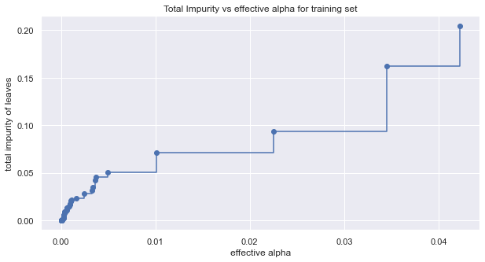

```python
# plot impurity vs alpha
fig, ax = plt.subplots(figsize=(10, 5))
ax.plot(ccp_alphas[:-1], impurities[:-1], marker="o", drawstyle="steps-post")
ax.set_xlabel("effective alpha")
ax.set_ylabel("total impurity of leaves")
ax.set_title("Total Impurity vs effective alpha for training set")
plt.show()
```

Train decision trees using the alphas.

```python
clfs = []
for ccp_alpha in ccp_alphas:
    clf = DecisionTreeClassifier(
        random_state=1, ccp_alpha=ccp_alpha, class_weight='balanced'
    )
    clf.fit(X_train, y_train)
    clfs.append(clf)
print(
    "Number of nodes in the last tree is: {} with ccp_alpha: {}".format(
        clfs[-1].tree_.node_count, ccp_alphas[-1]
    )
)
```

```
Number of nodes in the last tree is: 1 with ccp_alpha: 0.29537927599923186
```

We will remove the last alpha since it builds a trivial tree with one node and has no predictive value to the business.

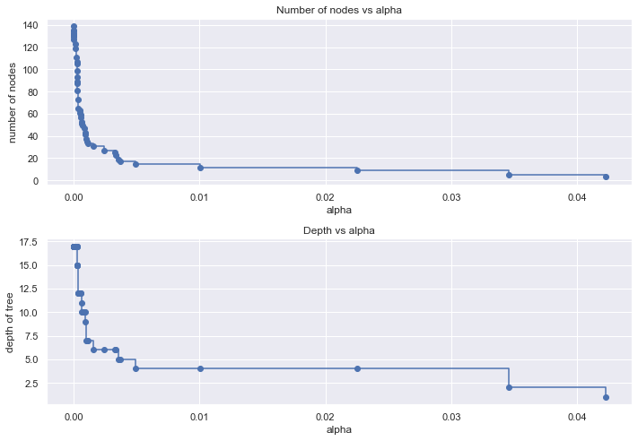

```python
# remove last model
clfs = clfs[:-1]
# remove last alpha
ccp_alphas = ccp_alphas[:-1]

# plot node count vs alpha
node_counts = [clf.tree_.node_count for clf in clfs]
depth = [clf.tree_.max_depth for clf in clfs]
fig, ax = plt.subplots(2, 1, figsize=(10, 7))
ax[0].plot(ccp_alphas, node_counts, marker="o", drawstyle="steps-post")
ax[0].set_xlabel("alpha")
ax[0].set_ylabel("number of nodes")
ax[0].set_title("Number of nodes vs alpha")
ax[1].plot(ccp_alphas, depth, marker="o", drawstyle="steps-post")
ax[1].set_xlabel("alpha")
ax[1].set_ylabel("depth of tree")
ax[1].set_title("Depth vs alpha")
fig.tight_layout()
```

##### Plot f1 scores for train and test against the various alphas

```python
# Get f1 scores from TRAIN data set
f1_train = []
for clf in clfs:
    pred_train = clf.predict(X_train)
    values_train = metrics.f1_score(y_train, pred_train)
    f1_train.append(values_train)

# Get f1 scores from TEST data set
f1_test = []
for clf in clfs:
    pred_test = clf.predict(X_test)
    values_test = metrics.f1_score(y_test, pred_test)
    f1_test.append(values_test)
```

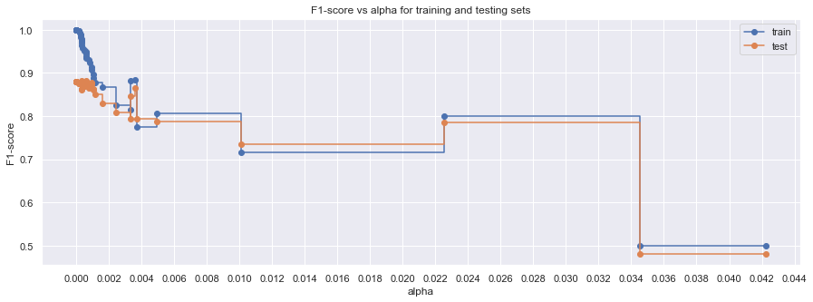

```python
fig, ax = plt.subplots(figsize=(15, 5))
ax.set_xlabel("alpha")
ax.set_ylabel("F1-score")
ax.set_title("F1-score vs alpha for training and testing sets")
ax.plot(
    ccp_alphas, f1_train, marker="o", label="train", drawstyle="steps-post",
)
ax.set_xticks(np.arange(0,0.05,0.002))
ax.grid(markevery=10, which='major')
ax.plot(ccp_alphas, f1_test, marker="o", label="test", drawstyle="steps-post")
ax.legend()
plt.show()
```

```python
# creating the model where we get highest train and test f1-score
index_best_model = np.argmax(f1_test)
best_model = clfs[index_best_model]
print(best_model)
```

```
DecisionTreeClassifier(ccp_alpha=0.0006292496529471483, class_weight='balanced',
                       random_state=1)
```

```python
get_metrics_score(best_model, X_train, X_test, y_train, y_test);
```

```
Accuracy - training      :  0.9877142857142858
Accuracy - test          :  0.9753333333333334
Recall - training        :  1.0
Recall - test            :  0.9261744966442953
Precision - training     :  0.8850267379679144
Precision - test         :  0.8414634146341463
F1 - training            :  0.9390070921985816
F1 - test                :  0.8817891373801916
```

```
Accuracy=0.975
Precision=0.841
Recall=0.926
F1 Score=0.882
```

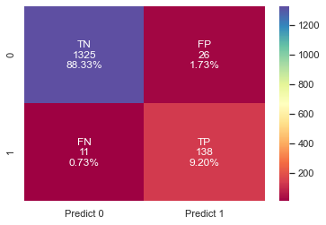

```python
plot_confusion_matrix(best_model, X_test, y_test )
```

Recall has much improved to 0.92 and Precision is still high at 0.84. F1-score for test is now 0.88.

#### Review tree with best model

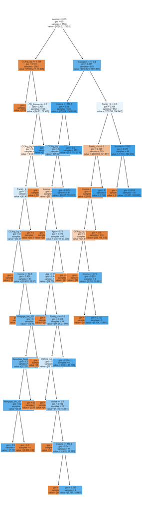

```python
plt.figure(figsize=(10,40))
out = tree.plot_tree(
    best_model,
    feature_names=feature_names,
    filled=True,
    fontsize=9,
    node_ids=False,
    class_names=None,
)
# below code will add arrows to the decision tree split if they are missing
for o in out:
    arrow = o.arrow_patch
    if arrow is not None:
        arrow.set_edgecolor("black")
        arrow.set_linewidth(1)
plt.show()
```

```python
# Text report with rules of decision tree
print(tree.export_text(dtm, feature_names=feature_names, show_weights=True, max_depth=20))
```

```
|--- Income <= 92.50
|   |--- CCAvg_log <= 1.10
|   |   |--- weights: [1344.67, 0.00] class: 0
|   |--- CCAvg_log >  1.10
|   |   |--- CD_Account <= 0.50
|   |   |   |--- CCAvg_log <= 1.39
|   |   |   |   |--- Family_4 <= 0.50
|   |   |   |   |   |--- CCAvg_log <= 1.13
|   |   |   |   |   |   |--- weights: [9.94, 0.00] class: 0
|   |   |   |   |   |--- CCAvg_log >  1.13
|   |   |   |   |   |   |--- Income <= 68.50
|   |   |   |   |   |   |   |--- weights: [4.97, 0.00] class: 0
|   |   |   |   |   |   |--- Income >  68.50
|   |   |   |   |   |   |   |--- Mortgage_bin_201 - 300 <= 0.50
|   |   |   |   |   |   |   |   |--- Securities_Account <= 0.50
|   |   |   |   |   |   |   |   |   |--- Mortgage_bin_101 - 200 <= 0.50
|   |   |   |   |   |   |   |   |   |   |--- Income <= 84.00
|   |   |   |   |   |   |   |   |   |   |   |--- ZIPCode_cat_95616 <= 0.50
|   |   |   |   |   |   |   |   |   |   |   |   |--- ZIPCode_cat_94720 <= 0.50
|   |   |   |   |   |   |   |   |   |   |   |   |   |--- CreditCard <= 0.50
|   |   |   |   |   |   |   |   |   |   |   |   |   |   |--- Income <= 82.50
|   |   |   |   |   |   |   |   |   |   |   |   |   |   |   |--- Online <= 0.50
|   |   |   |   |   |   |   |   |   |   |   |   |   |   |   |   |--- weights: [1.10, 0.00] class: 0
|   |   |   |   |   |   |   |   |   |   |   |   |   |   |   |--- Online >  0.50
|   |   |   |   |   |   |   |   |   |   |   |   |   |   |   |   |--- CCAvg_log <= 1.33
|   |   |   |   |   |   |   |   |   |   |   |   |   |   |   |   |   |--- weights: [0.00, 15.86] class: 1
|   |   |   |   |   |   |   |   |   |   |   |   |   |   |   |   |--- CCAvg_log >  1.33
|   |   |   |   |   |   |   |   |   |   |   |   |   |   |   |   |   |--- weights: [0.55, 0.00] class: 0
|   |   |   |   |   |   |   |   |   |   |   |   |   |   |--- Income >  82.50
|   |   |   |   |   |   |   |   |   |   |   |   |   |   |   |--- weights: [0.00, 26.44] class: 1
|   |   |   |   |   |   |   |   |   |   |   |   |   |--- CreditCard >  0.50
|   |   |   |   |   |   |   |   |   |   |   |   |   |   |--- Online <= 0.50
|   |   |   |   |   |   |   |   |   |   |   |   |   |   |   |--- weights: [0.00, 5.29] class: 1
|   |   |   |   |   |   |   |   |   |   |   |   |   |   |--- Online >  0.50
|   |   |   |   |   |   |   |   |   |   |   |   |   |   |   |--- weights: [1.66, 0.00] class: 0
|   |   |   |   |   |   |   |   |   |   |   |   |--- ZIPCode_cat_94720 >  0.50
|   |   |   |   |   |   |   |   |   |   |   |   |   |--- weights: [0.55, 0.00] class: 0
|   |   |   |   |   |   |   |   |   |   |   |--- ZIPCode_cat_95616 >  0.50
|   |   |   |   |   |   |   |   |   |   |   |   |--- weights: [0.55, 0.00] class: 0
|   |   |   |   |   |   |   |   |   |   |--- Income >  84.00
```

[output cut: 153 more lines]

```
|   |   |   |   |--- weights: [6.07, 0.00] class: 0
|   |   |   |--- Income >  108.50
|   |   |   |   |--- Age <= 26.00
|   |   |   |   |   |--- weights: [0.55, 0.00] class: 0
|   |   |   |   |--- Age >  26.00
|   |   |   |   |   |--- Income <= 118.00
|   |   |   |   |   |   |--- Online <= 0.50
|   |   |   |   |   |   |   |--- weights: [0.00, 10.57] class: 1
|   |   |   |   |   |   |--- Online >  0.50
|   |   |   |   |   |   |   |--- CCAvg_log <= 0.77
|   |   |   |   |   |   |   |   |--- weights: [0.55, 0.00] class: 0
|   |   |   |   |   |   |   |--- CCAvg_log >  0.77
|   |   |   |   |   |   |   |   |--- weights: [0.55, 0.00] class: 0
|   |   |   |   |   |--- Income >  118.00
|   |   |   |   |   |   |--- weights: [0.00, 174.47] class: 1
```

However, the three is still quite complex. We can use a higher alpha to reduce number of nodes/depth.

From the f1-score vs alpha graph we can see that we can achieve high f1 score with alpha of approximately 0.004

```
[array([ 0,  1,  2,  3,  4,  5,  6,  7,  8,  9, 10, 11, 12, 13, 14, 15, 16,
       17, 18, 19, 20, 21, 22, 23, 24, 25, 26, 27, 28, 29, 30, 31, 32, 33,
       34, 35, 36, 37], dtype=int64)]
```

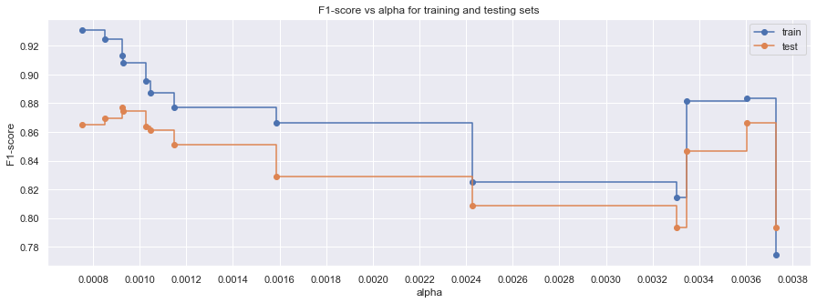

```python
# zoom in to area near alpha of 0.004
fig, ax = plt.subplots(figsize=(15, 5))
ax.set_xlabel("alpha")
ax.set_ylabel("F1-score")
ax.set_title("F1-score vs alpha for training and testing sets")
alphas_zoom_idx = list(np.where(ccp_alphas < 0.0042))
print(alphas_zoom_idx)
ax.plot(
    ccp_alphas[25:38], f1_train[25:38], marker="o", label="train", drawstyle="steps-post",
)
ax.set_xticks(np.arange(0,0.05,0.0002))
ax.grid(markevery=10, which='major')
ax.plot(ccp_alphas[25:38], f1_test[25:38], marker="o", label="test", drawstyle="steps-post")
ax.legend()
plt.show()
```

We will create a model with alpha of 0.0036

```python
best_model2 = DecisionTreeClassifier(
    ccp_alpha=0.0036, class_weight='balanced', random_state=1
)
best_model2.fit(X_train, y_train)
```

```
DecisionTreeClassifier(ccp_alpha=0.0036, class_weight='balanced',
                       random_state=1)
```

```python
get_metrics_score(best_model2, X_train, X_test, y_train, y_test);
```

```
Accuracy - training      :  0.9754285714285714
Accuracy - test          :  0.966
Recall - training        :  0.9697885196374623
Recall - test            :  0.9463087248322147
Precision - training     :  0.8085642317380353
Precision - test         :  0.7663043478260869
F1 - training            :  0.881868131868132
F1 - test                :  0.8468468468468467
```

```
Accuracy=0.966
Precision=0.766
Recall=0.946
F1 Score=0.847
```

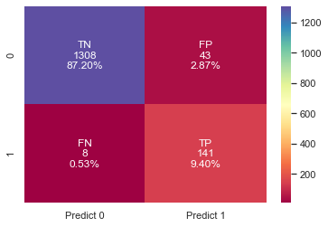

```python
plot_confusion_matrix(best_model2, X_test, y_test)
```

Recall has improved to 0.94 from 0.92 with prior model. Precision descreased from 0.84 to 0.77.

F1-score has descreased from 0.88 to 0.84

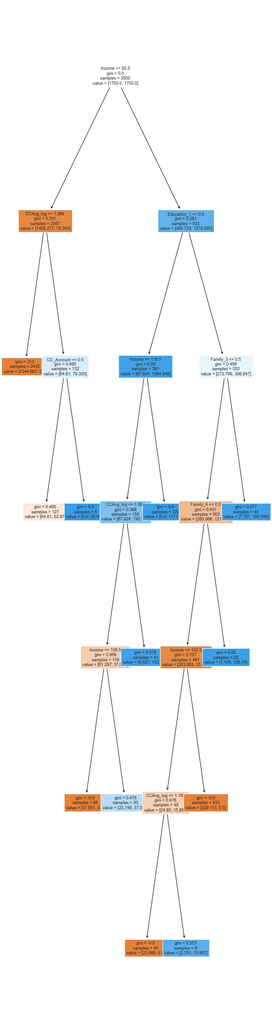

```python
plt.figure(figsize=(10,40))
out = tree.plot_tree(
    best_model2,
    feature_names=feature_names,
    filled=True,
    fontsize=9,
    node_ids=False,
    class_names=None,
)
# below code will add arrows to the decision tree split if they are missing
for o in out:
    arrow = o.arrow_patch
    if arrow is not None:
        arrow.set_edgecolor("black")
        arrow.set_linewidth(1)
plt.show()
```

```python
# Text report with rules of decision tree
print(tree.export_text(best_model2, feature_names=feature_names, show_weights=True, max_depth=20))
```

```
|--- Income <= 92.50
|   |--- CCAvg_log <= 1.10
|   |   |--- weights: [1344.67, 0.00] class: 0
|   |--- CCAvg_log >  1.10
|   |   |--- CD_Account <= 0.50
|   |   |   |--- weights: [64.61, 52.87] class: 0
|   |   |--- CD_Account >  0.50
|   |   |   |--- weights: [0.00, 26.44] class: 1
|--- Income >  92.50
|   |--- Education_1 <= 0.50
|   |   |--- Income <= 116.50
|   |   |   |--- CCAvg_log <= 1.06
|   |   |   |   |--- Income <= 106.50
|   |   |   |   |   |--- weights: [37.55, 0.00] class: 0
|   |   |   |   |--- Income >  106.50
|   |   |   |   |   |--- weights: [23.75, 37.01] class: 1
|   |   |   |--- CCAvg_log >  1.06
|   |   |   |   |--- weights: [6.63, 153.32] class: 1
|   |   |--- Income >  116.50
|   |   |   |--- weights: [0.00, 1173.72] class: 1
|   |--- Education_1 >  0.50
|   |   |--- Family_3 <= 0.50
|   |   |   |--- Family_4 <= 0.50
|   |   |   |   |--- Income <= 103.50
|   |   |   |   |   |--- CCAvg_log <= 1.18
|   |   |   |   |   |   |--- weights: [22.09, 0.00] class: 0
|   |   |   |   |   |--- CCAvg_log >  1.18
|   |   |   |   |   |   |--- weights: [2.76, 15.86] class: 1
|   |   |   |   |--- Income >  103.50
|   |   |   |   |   |--- weights: [239.11, 0.00] class: 0
|   |   |   |--- Family_4 >  0.50
|   |   |   |   |--- weights: [1.10, 105.74] class: 1
|   |   |--- Family_3 >  0.50
|   |   |   |--- weights: [7.73, 185.05] class: 1
```

Decision tree has lower complexity and is easier to interpret.

The tree complexity has decreased and is easier to interpret. We consider best_model2 the best decision tree model.

```python
# importance of features using Gini importance
print(
    pd.DataFrame(
        best_model2.feature_importances_, columns=["Imp"], index=X_train.columns,
    ).sort_values(by="Imp", ascending=False)
)
```

```
                             Imp
Income                  0.669886
Education_1             0.090805
CCAvg_log               0.082822
Family_4                0.082659
Family_3                0.065812
CD_Account              0.008016
ZIPCode_cat_94305       0.000000
ZIPCode_cat_94720       0.000000
ZIPCode_cat_95616       0.000000
ZIPCode_cat_Other       0.000000
Age                     0.000000
ZIPCode_cat_93943       0.000000
Mortgage_bin_0          0.000000
Mortgage_bin_1 - 100    0.000000
Mortgage_bin_101 - 200  0.000000
Mortgage_bin_201 - 300  0.000000
Mortgage_bin_301 - 400  0.000000
ZIPCode_cat_94025       0.000000
ZIPCode_cat_91320       0.000000
ZIPCode_cat_93106       0.000000
ZIPCode_cat_92037       0.000000
ZIPCode_cat_91711       0.000000
ZIPCode_cat_90095       0.000000
Education_3             0.000000
Education_2             0.000000
Family_2                0.000000
Family_1                0.000000
CreditCard              0.000000
Online                  0.000000
Securities_Account      0.000000
Mortgage_bin_> 400      0.000000
```

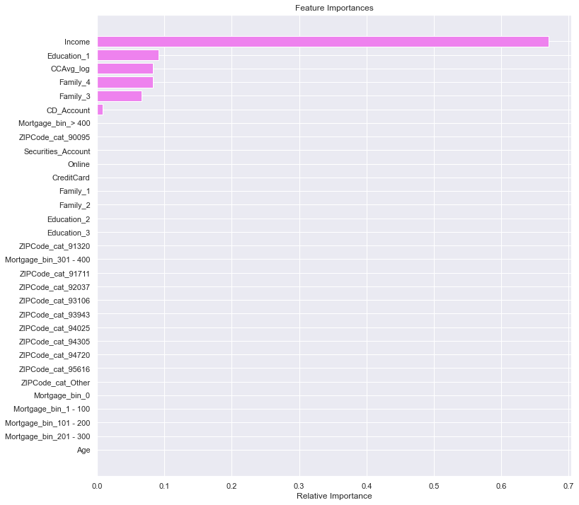

```python
# plot importance graph
importances = best_model2.feature_importances_
indices = np.argsort(importances)

plt.figure(figsize=(12, 12))
plt.title("Feature Importances")
plt.barh(range(len(indices)), importances[indices], color="violet", align="center")
plt.yticks(range(len(indices)), [feature_names[i] for i in indices])
plt.xlabel("Relative Importance")
plt.show()
```

The most important feature is Income, followed by Education_1 (Undergraduate), CCAvg_log (log of credit card avg expenditures), Family 3 and 4 and last CD_Account.

#### Decision Tree Features Importance Interpretation

- Customers with Income <= 92.5 are more likely to accept a loan if they also have a CD account
- Customers with Income above > 92.5 are more likely to accept a loan:
  - if their education is higher than Undergraduate, or,
  - if their education is undergraduate, and family size is 3 or 4
- Customers are more likely to accept a loan if their monthly credit card average spending is higher than approx. 3000 USD.

## Conclusions

- We have analyzed data for bank customers and used Logistic Regression and Decision Tree models to create a predictive model.
- The models can be used to predict whether a customer is going to accept a loan offer from the bank
- Although we considered the lost opportunity cost of a False Negative higher than a False Positive we optimized Recall and f1-score rather than Recall alone. A model that has high Recall but also very high rate of False Positives (low Precision) is not informative.
- The Decision tree (DT) model chosen shows higher performance metrics than the logistic regression (LR). The best DT model has an f1-score of 0.85 with a Recall of 0.94 vs f1-score of 0.73 and Recall of 0.738 for the LR.
- The decision tree fit to the data indicates that the most important predictors are Income, Education, Credit Card expenditure and Family size.

## Recommendations

- Use the predictive model to identify current customers who are very likely to accept a loan offer and target them as part of a campaign.
- Based on the decision tree model, ZIP code is not a significant predictor of accepting a loan offer. Campaign should not focus on ZIP code as determinant of campaign strategy.
- Customers with high credit cards transactions values are more likely to accept a loan. A campaign should target those customers.
- Low acceptance rates of loan offers by smaller families of one or two might indicate there is an opportunitiy to target more specifically those segments to increase the acceptance rate.
- Lower acceptance rates of customers with Undergraduate education, suggests there might be an opportunity to raise acceptance rates in this customer segment.
- The models indicate that income is the best predictor for accepting a loan offer. Future campaigns should target high income customers with tailored loan offers.